# Data Cleansing Essentials with R

Australia Sales Dataset Analysis

Data Science Project

2025-09-04

# Introduction

This document demonstrates comprehensive data cleansing techniques using R on the Australia Sales Dataset. Data cleansing is a critical step in the data analysis pipeline that ensures data quality and reliability for downstream analysis and machine learning applications.

## Objectives

- Implement systematic data cleansing workflow
- Demonstrate data quality assessment techniques
- Show practical solutions for common data issues
- Create reusable data cleaning functions
- Generate comprehensive data quality reports

## Dataset Overview

The Australia Sales Dataset contains retail transaction data from three major Australian cities: Sydney, Melbourne, and Perth. The dataset includes 1,000 transactions with 17 columns covering transaction details, customer information, and financial data.

# Setup and Package Loading

```r
# Install packages if needed
required_packages <- c("tidyverse", "janitor", "naniar", "lubridate",
                       "stringr", "forcats", "skimr", "readxl", "here", "gridExtra")

install_if_missing <- function(package) {
  if (!require(package, character.only = TRUE)) {
    install.packages(package, dependencies = TRUE, repos = "https://cran.rstudio.com/")
    library(package, character.only = TRUE)
  }
}

# Load all required packages
invisible(sapply(required_packages, install_if_missing))

# Create output directories
dir.create("images", showWarnings = FALSE, recursive = TRUE)
dir.create("Dataset", showWarnings = FALSE, recursive = TRUE)
```

# Data Loading and Initial Assessment

## Loading the Dataset

```r
# Load the dataset with explicit column types
data_path <- "Dataset/australia_sales.csv"
sales_data <- readr::read_csv(
  file = data_path,
  col_types = cols(
    `Invoice ID` = col_character(),
    Branch = col_character(),
    City = col_character(),
    `Customer type` = col_character(),
    Gender = col_character(),
    `Product line` = col_character(),
    `Unit price` = col_double(),
    Quantity = col_double(),
    `Tax 5%` = col_double(),
    Total = col_double(),
    Date = col_character(),
    Time = col_character(),
    Payment = col_character(),
    cogs = col_double(),
    `gross margin percentage` = col_double(),
    `gross income` = col_double(),
    Rating = col_double()
  ),
  locale = locale(decimal_mark = ".", grouping_mark = ",")
)

# Check for parsing issues
parsing_issues <- readr::problems(sales_data)
if (nrow(parsing_issues) > 0) {
  cat("Warning: Found", nrow(parsing_issues), "parsing issues\n")
  print(parsing_issues)
} else {
  cat("✓ No parsing issues found\n")
}
```

```
#> ✓ No parsing issues found
```

## Initial Data Overview

```r
# Dataset dimensions and basic info
cat("Dataset dimensions:", nrow(sales_data), "rows ×", ncol(sales_data), "columns\n")
```

```
#> Dataset dimensions: 1000 rows × 17 columns
```

```r
cat("Memory usage:", format(object.size(sales_data), units = "MB"), "\n")
```

```
#> Memory usage: 0.2 Mb
```

```r
# Display first few rows
head(sales_data, 10)
```

```
#> # A tibble: 10 × 17
#>    `Invoice ID` Branch City   `Customer type` Gender `Product line` `Unit price`
#>    <chr>        <chr>  <chr>  <chr>           <chr>  <chr>                 <dbl>
#>  1 750-67-8428  A      Sydney Member          Female Health and be…         74.7
#>  2 226-31-3081  C      Perth  Normal          Female Electronic ac…         15.3
#>  3 631-41-3108  A      Sydney Normal          Male   Home and life…         46.3
#>  4 123-19-1176  A      Sydney Member          Male   Health and be…         58.2
#>  5 373-73-7910  A      Sydney Normal          Male   Sports and tr…         86.3
#>  6 699-14-3026  C      Perth  Normal          Male   Electronic ac…         85.4
#>  7 355-53-5943  A      Sydney Member          Female Electronic ac…         68.8
#>  8 315-22-5665  C      Perth  Normal          Female Home and life…         73.6
#>  9 665-32-9167  A      Sydney Member          Female Health and be…         36.3
#> 10 692-92-5582  B      Melbo… Member          Female Food and beve…         54.8
#> # ℹ 10 more variables: Quantity <dbl>, `Tax 5%` <dbl>, Total <dbl>, Date <chr>,
#> #   Time <chr>, Payment <chr>, cogs <dbl>, `gross margin percentage` <dbl>,
#> #   `gross income` <dbl>, Rating <dbl>
```

```r
# Data structure
str(sales_data)
```

```
#> spc_tbl_ [1,000 × 17] (S3: spec_tbl_df/tbl_df/tbl/data.frame)
#>  $ Invoice ID             : chr [1:1000] "750-67-8428" "226-31-3081" "631-41-3108" "123-19-1176" ...
#>  $ Branch                 : chr [1:1000] "A" "C" "A" "A" ...
#>  $ City                   : chr [1:1000] "Sydney" "Perth" "Sydney" "Sydney" ...
#>  $ Customer type          : chr [1:1000] "Member" "Normal" "Normal" "Member" ...
#>  $ Gender                 : chr [1:1000] "Female" "Female" "Male" "Male" ...
#>  $ Product line           : chr [1:1000] "Health and beauty" "Electronic accessories" "Home and lifestyle" "Health and beauty" ...
#>  $ Unit price             : num [1:1000] 74.7 15.3 46.3 58.2 86.3 ...
#>  $ Quantity               : num [1:1000] 7 5 7 8 7 7 6 10 2 3 ...
#>  $ Tax 5%                 : num [1:1000] 26.14 3.82 16.22 23.29 30.21 ...
#>  $ Total                  : num [1:1000] 549 80.2 340.5 489 634.4 ...
#>  $ Date                   : chr [1:1000] "1/5/2019" "3/8/2019" "3/3/2019" "1/27/2019" ...
#>  $ Time                   : chr [1:1000] "13:08" "10:29" "13:23" "20:33" ...
#>  $ Payment                : chr [1:1000] "Ewallet" "Cash" "Credit card" "Ewallet" ...
#>  $ cogs                   : num [1:1000] 522.8 76.4 324.3 465.8 604.2 ...
#>  $ gross margin percentage: num [1:1000] 4.76 4.76 4.76 4.76 4.76 ...
#>  $ gross income           : num [1:1000] 26.14 3.82 16.22 23.29 30.21 ...
#>  $ Rating                 : num [1:1000] 9.1 9.6 7.4 8.4 5.3 4.1 5.8 8 7.2 5.9 ...
#>  - attr(*, "spec")=
#>   .. cols(
#>   ..   `Invoice ID` = col_character(),
#>   ..   Branch = col_character(),
#>   ..   City = col_character(),
#>   ..   `Customer type` = col_character(),
#>   ..   Gender = col_character(),
#>   ..   `Product line` = col_character(),
#>   ..   `Unit price` = col_double(),
#>   ..   Quantity = col_double(),
#>   ..   `Tax 5%` = col_double(),
#>   ..   Total = col_double(),
#>   ..   Date = col_character(),
#>   ..   Time = col_character(),
#>   ..   Payment = col_character(),
#>   ..   cogs = col_double(),
#>   ..   `gross margin percentage` = col_double(),
#>   ..   `gross income` = col_double(),
#>   ..   Rating = col_double()
#>   .. )
#>  - attr(*, "problems")=<externalptr>
```

# Data Quality Assessment

## Missing Values Analysis

```r
# Missing values summary
missing_summary <- naniar::miss_var_summary(sales_data)
print(missing_summary)
```

```
#> # A tibble: 17 × 3
#>    variable                n_miss pct_miss
#>    <chr>                    <int>    <num>
#>  1 Invoice ID                   0        0
#>  2 Branch                       0        0
#>  3 City                         0        0
#>  4 Customer type                0        0
#>  5 Gender                       0        0
#>  6 Product line                 0        0
#>  7 Unit price                   0        0
#>  8 Quantity                     0        0
#>  9 Tax 5%                       0        0
#> 10 Total                        0        0
#> 11 Date                         0        0
#> 12 Time                         0        0
#> 13 Payment                      0        0
#> 14 cogs                         0        0
#> 15 gross margin percentage      0        0
#> 16 gross income                 0        0
#> 17 Rating                       0        0
```

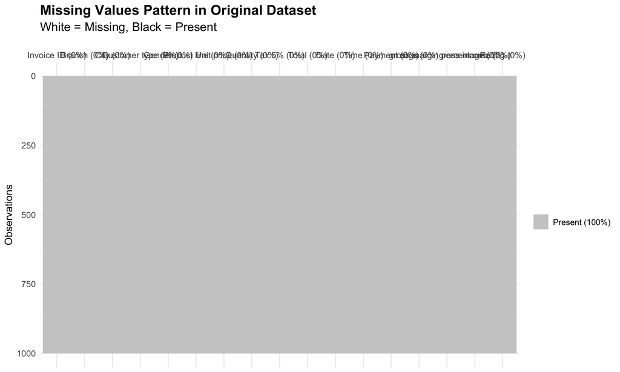

TRUE

```r
# Visualize missing values
naniar::vis_miss(sales_data, warn_large_data = FALSE) +
  theme_minimal() +
  theme(plot.background = element_rect(fill = "white", color = NA),
        text = element_text(size = 12),
        axis.text = element_text(size = 10),
        plot.title = element_text(size = 16, face = "bold"),
        plot.subtitle = element_text(size = 14)) +
  labs(title = "Missing Values Pattern in Original Dataset",
       subtitle = "White = Missing, Black = Present")
```

## Data Types Analysis

```r
# Data types summary
data_types <- sapply(sales_data, class)
print(data_types)
```

```
#>              Invoice ID                  Branch                    City
#>             "character"             "character"             "character"
#>           Customer type                  Gender            Product line
#>             "character"             "character"             "character"
#>              Unit price                Quantity                  Tax 5%
#>               "numeric"               "numeric"               "numeric"
#>                   Total                    Date                    Time
#>               "numeric"             "character"             "character"
#>                 Payment                    cogs gross margin percentage
#>             "character"               "numeric"               "numeric"
#>            gross income                  Rating
#>               "numeric"               "numeric"
```

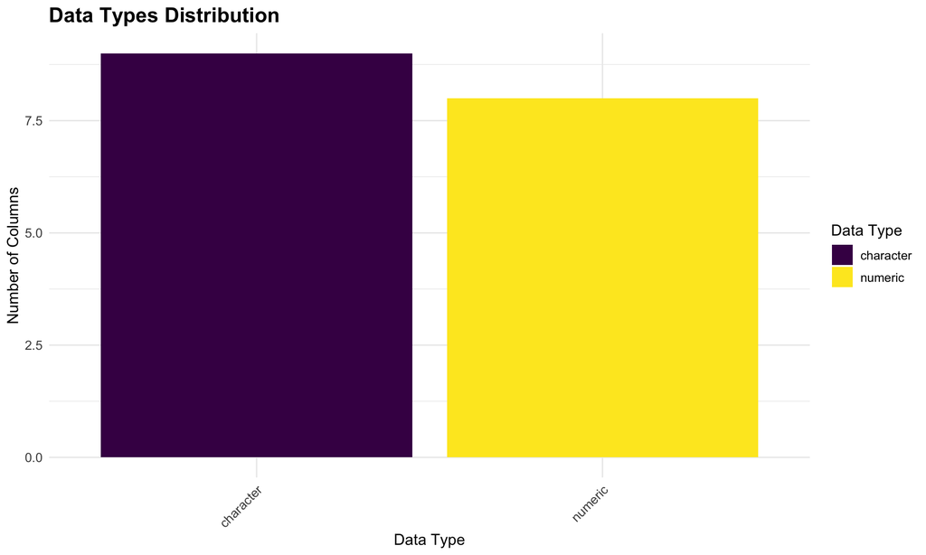

TRUE

```r
# Visualize data types distribution
data_types_df <- data.frame(
  column = names(sales_data),
  type = sapply(sales_data, class)
)

ggplot(data_types_df, aes(x = type, fill = type)) +
  geom_bar() +
  theme_minimal() +
  theme(plot.background = element_rect(fill = "white", color = NA),
        text = element_text(size = 12),
        axis.text = element_text(size = 10),
        plot.title = element_text(size = 16, face = "bold"),
        axis.text.x = element_text(angle = 45, hjust = 1, size = 10)) +
  labs(title = "Data Types Distribution",
       x = "Data Type",
       y = "Number of Columns",
       fill = "Data Type") +
  scale_fill_viridis_d()
```

## Basic Statistics

```r
# Comprehensive data summary
summary_stats <- skimr::skim(sales_data)
print(summary_stats)
```

```
#> ── Data Summary ────────────────────────
#>                            Values
#> Name                       sales_data
#> Number of rows             1000
#> Number of columns          17
#> _______________________
#> Column type frequency:
#>   character                9
#>   numeric                  8
#> ________________________
#> Group variables            None
#>
#> ── Variable type: character ────────────────────────────────────────────────────
#>   skim_variable n_missing complete_rate min max empty n_unique whitespace
#> 1 Invoice ID            0             1  11  11     0     1000          0
#> 2 Branch                0             1   1   1     0        3          0
#> 3 City                  0             1   5   9     0        3          0
#> 4 Customer type         0             1   6   6     0        2          0
#> 5 Gender                0             1   4   6     0        2          0
#> 6 Product line          0             1  17  22     0        6          0
#> 7 Date                  0             1   8   9     0       89          0
#> 8 Time                  0             1   5   5     0      506          0
#> 9 Payment               0             1   4  11     0        3          0
#>
#> ── Variable type: numeric ──────────────────────────────────────────────────────
#>   skim_variable           n_missing complete_rate   mean     sd     p0    p25
#> 1 Unit price                      0             1  55.7   26.5  10.1    32.9
#> 2 Quantity                        0             1   5.51   2.92  1       3
#> 3 Tax 5%                          0             1  15.4   11.7   0.508   5.92
#> 4 Total                           0             1 323.   246.   10.7   124.
#> 5 cogs                            0             1 308.   234.   10.2   118.
#> 6 gross margin percentage         0             1   4.76   0     4.76    4.76
#> 7 gross income                    0             1  15.4   11.7   0.508   5.92
#> 8 Rating                          0             1   6.97   1.72  4       5.5
#>      p50    p75    p100 hist
#> 1  55.2   77.9   100.   ▇▇▇▇▇
#> 2   5      8      10    ▇▇▇▇▇
#> 3  12.1   22.4    49.6  ▇▅▃▂▁
#> 4 254.   471.   1043.   ▇▅▃▂▁
#> 5 242.   449.    993    ▇▅▃▂▁
#> 6   4.76   4.76    4.76 ▁▁▇▁▁
#> 7  12.1   22.4    49.6  ▇▅▃▂▁
#> 8   7      8.5    10    ▇▇▇▇▇
```

# Data Standardization

## Column Name Cleaning

```r
# Clean column names to snake_case format
sales_clean <- sales_data %>%
  janitor::clean_names()

cat("Column names cleaned to snake_case format\n")
```

```
#> Column names cleaned to snake_case format
```

```r
cat("Original columns:", paste(names(sales_data), collapse = ", "), "\n")
```

```
#> Original columns: Invoice ID, Branch, City, Customer type, Gender, Product line, Unit price, Quantity, Tax 5%, Total, Date, Time, Payment, cogs, gross margin percentage, gross income, Rating
```

```r
cat("Cleaned columns:", paste(names(sales_clean), collapse = ", "), "\n")
```

```
#> Cleaned columns: invoice_id, branch, city, customer_type, gender, product_line, unit_price, quantity, tax_5_percent, total, date, time, payment, cogs, gross_margin_percentage, gross_income, rating
```

## Data Type Conversion

```r
# Convert data types appropriately
sales_clean <- sales_clean %>%
  mutate(
    # Parse dates
    date_parsed = lubridate::mdy(date, quiet = TRUE),

    # Parse times
    time_parsed = lubridate::hm(time),

    # Convert to factors
    branch = as_factor(branch),
    city = as_factor(city),
    customer_type = as_factor(customer_type),
    gender = as_factor(gender),
    product_line = as_factor(product_line),
    payment = as_factor(payment),

    # Ensure numeric types
    unit_price = as.numeric(unit_price),
    quantity = as.numeric(quantity),
    tax_5_percent = as.numeric(tax_5_percent),
    total = as.numeric(total),
    cogs = as.numeric(cogs),
    gross_margin_percentage = as.numeric(gross_margin_percentage),
    gross_income = as.numeric(gross_income),
    rating = as.numeric(rating)
  )

# Check for parsing issues
na_dates <- sum(is.na(sales_clean$date_parsed))
na_times <- sum(is.na(sales_clean$time_parsed))

cat("Date parsing: ", na_dates, "failed dates out of", nrow(sales_clean), "total\n")
```

```
#> Date parsing:  0 failed dates out of 1000 total
```

```r
cat("Time parsing: ", na_times, "failed times out of", nrow(sales_clean), "total\n")
```

```
#> Time parsing:  0 failed times out of 1000 total
```

# Missing Value Treatment

## Missing Values After Type Conversion

```r
# Check missing values after type conversion
missing_after_conversion <- naniar::miss_var_summary(sales_clean)
print(missing_after_conversion)
```

```
#> # A tibble: 19 × 3
#>    variable                n_miss pct_miss
#>    <chr>                    <int>    <num>
#>  1 invoice_id                   0        0
#>  2 branch                       0        0
#>  3 city                         0        0
#>  4 customer_type                0        0
#>  5 gender                       0        0
#>  6 product_line                 0        0
#>  7 unit_price                   0        0
#>  8 quantity                     0        0
#>  9 tax_5_percent                0        0
#> 10 total                        0        0
#> 11 date                         0        0
#> 12 time                         0        0
#> 13 payment                      0        0
#> 14 cogs                         0        0
#> 15 gross_margin_percentage      0        0
#> 16 gross_income                 0        0
#> 17 rating                       0        0
#> 18 date_parsed                  0        0
#> 19 time_parsed                  0        0
```

## Missing Value Imputation

```r
# Handle missing values with appropriate strategies
sales_clean <- sales_clean %>%
  mutate(
    # Fill missing cities with "Unknown"
    city = fct_explicit_na(city, na_level = "Unknown"),

    # Fill missing ratings with median
    rating = ifelse(is.na(rating), median(rating, na.rm = TRUE), rating),

    # Create missing value indicators
    city_missing = as.integer(city == "Unknown"),
    rating_missing = as.integer(is.na(rating))
  )

# Remove rows with missing critical data
initial_rows <- nrow(sales_clean)
sales_clean <- sales_clean %>%
  filter(!is.na(invoice_id), !is.na(unit_price), !is.na(quantity))

final_rows <- nrow(sales_clean)
removed_rows <- initial_rows - final_rows

cat("Removed", removed_rows, "rows with missing critical data\n")
```

```
#> Removed 0 rows with missing critical data
```

```r
cat("Final dataset:", final_rows, "rows\n")
```

```
#> Final dataset: 1000 rows
```

# Outlier Detection and Treatment

## Outlier Detection

```r
# Define numeric columns for outlier analysis
numeric_cols <- c("unit_price", "quantity", "total", "rating")

# IQR-based outlier detection function
outlier_detection <- function(x, multiplier = 1.5) {
  Q1 <- quantile(x, 0.25, na.rm = TRUE)
  Q3 <- quantile(x, 0.75, na.rm = TRUE)
  IQR <- Q3 - Q1
  lower <- Q1 - multiplier * IQR
  upper <- Q3 + multiplier * IQR
  return(x < lower | x > upper)
}

# Detect outliers
outlier_summary <- sales_clean %>%
  summarise(across(all_of(numeric_cols), list(
    outliers = ~sum(outlier_detection(.x), na.rm = TRUE),
    outlier_pct = ~round(100 * sum(outlier_detection(.x), na.rm = TRUE) / length(.x), 2)
  )))

print(outlier_summary)
```

```
#> # A tibble: 1 × 8
#>   unit_price_outliers unit_price_outlier_pct quantity_outliers
#>                 <int>                  <dbl>             <int>
#> 1                   0                      0                 0
#> # ℹ 5 more variables: quantity_outlier_pct <dbl>, total_outliers <int>,
#> #   total_outlier_pct <dbl>, rating_outliers <int>, rating_outlier_pct <dbl>
```

## Outlier Visualization

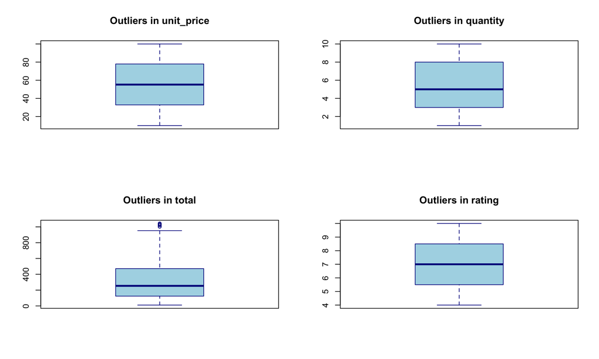

TRUE

```r
# Create box plots for outlier visualization
par(mfrow = c(2, 2))
for (col in numeric_cols) {
  boxplot(sales_clean[[col]], main = paste("Outliers in", col),
          col = "lightblue", border = "darkblue")
}
```

## Outlier Treatment

```r
# Winsorization function
winsorize <- function(x, p_low = 0.01, p_high = 0.99) {
  lo <- quantile(x, p_low, na.rm = TRUE)
  hi <- quantile(x, p_high, na.rm = TRUE)
  pmin(pmax(x, lo), hi)
}

# Apply winsorization to extreme outliers
sales_clean <- sales_clean %>%
  mutate(
    unit_price_winsorized = winsorize(unit_price),
    quantity_winsorized = winsorize(quantity),
    total_winsorized = winsorize(total),
    rating_winsorized = winsorize(rating)
  )

# Create outlier flags
sales_clean <- sales_clean %>%
  mutate(
    unit_price_outlier = outlier_detection(unit_price),
    quantity_outlier = outlier_detection(quantity),
    total_outlier = outlier_detection(total),
    rating_outlier = outlier_detection(rating)
  )
```

# Text Normalization

## Categorical Value Standardization

```r
# Standardize text fields
sales_clean <- sales_clean %>%
  mutate(
    # Standardize city names
    city = fct_recode(city,
                      "Sydney" = "sydney",
                      "Melbourne" = "melbourne",
                      "Perth" = "perth"),

    # Standardize product line names
    product_line = fct_recode(product_line,
                              "Health and Beauty" = "Health and beauty",
                              "Electronic Accessories" = "Electronic accessories",
                              "Home and Lifestyle" = "Home and lifestyle",
                              "Sports and Travel" = "Sports and travel",
                              "Food and Beverages" = "Food and beverages",
                              "Fashion Accessories" = "Fashion accessories"),

    # Standardize payment methods
    payment = fct_recode(payment,
                         "E-wallet" = "Ewallet",
                         "Credit Card" = "Credit card"),

    # Relevel factors for consistent ordering
    city = fct_relevel(city, "Sydney", "Melbourne", "Perth", "Unknown"),
    customer_type = fct_relevel(customer_type, "Member", "Normal"),
    gender = fct_relevel(gender, "Male", "Female")
  )
```

## Categorical Analysis

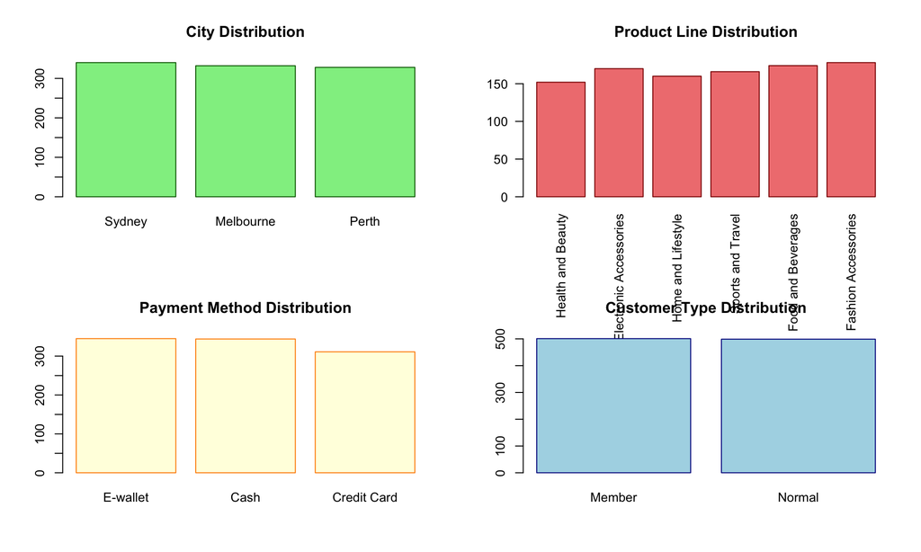

TRUE

```r
# Visualize categorical distributions
par(mfrow = c(2, 2))

# City distribution
barplot(table(sales_clean$city), main = "City Distribution",
        col = "lightgreen", border = "darkgreen")

# Product line distribution
barplot(table(sales_clean$product_line), main = "Product Line Distribution",
        col = "lightcoral", border = "darkred", las = 2)

# Payment method distribution
barplot(table(sales_clean$payment), main = "Payment Method Distribution",
        col = "lightyellow", border = "darkorange")

# Customer type distribution
barplot(table(sales_clean$customer_type), main = "Customer Type Distribution",
        col = "lightblue", border = "darkblue")
```

# Data Validation

## Business Rule Validation

```r
# Business rule validations
validation_results <- sales_clean %>%
  mutate(
    # Check if total equals quantity * unit_price + tax
    total_calculated = quantity * unit_price + tax_5_percent,
    total_diff = abs(total - total_calculated),
    total_valid = total_diff < 0.01,  # Allow small rounding differences

    # Check if tax is 5% of subtotal
    subtotal = quantity * unit_price,
    tax_calculated = subtotal * 0.05,
    tax_diff = abs(tax_5_percent - tax_calculated),
    tax_valid = tax_diff < 0.01,

    # Check rating range
    rating_valid = rating >= 1 & rating <= 10,

    # Check positive values
    price_valid = unit_price > 0,
    quantity_valid = quantity > 0,
    total_valid_amount = total > 0
  )

# Summary of validation results
validation_summary <- validation_results %>%
  summarise(
    total_calculation_errors = sum(!total_valid, na.rm = TRUE),
    tax_calculation_errors = sum(!tax_valid, na.rm = TRUE),
    invalid_ratings = sum(!rating_valid, na.rm = TRUE),
    negative_prices = sum(!price_valid, na.rm = TRUE),
    negative_quantities = sum(!quantity_valid, na.rm = TRUE),
    negative_totals = sum(!total_valid_amount, na.rm = TRUE)
  )

print(validation_summary)
```

```
#> # A tibble: 1 × 6
#>   total_calculation_err…¹ tax_calculation_errors invalid_ratings negative_prices
#>                     <int>                  <int>           <int>           <int>
#> 1                       0                      0               0               0
#> # ℹ abbreviated name: ¹total_calculation_errors
#> # ℹ 2 more variables: negative_quantities <int>, negative_totals <int>
```

# Duplicate Detection

## Duplicate Analysis

```r
# Check for exact duplicates
exact_duplicates <- janitor::get_dupes(sales_clean, invoice_id)
cat("Exact duplicates by invoice_id:", nrow(exact_duplicates), "\n")
```

```
#> Exact duplicates by invoice_id: 0
```

```r
# Check for potential duplicates (same invoice_id, different other fields)
potential_duplicates <- sales_clean %>%
  group_by(invoice_id) %>%
  filter(n() > 1) %>%
  arrange(invoice_id)

cat("Potential duplicates (same invoice_id, different details):", nrow(potential_duplicates), "\n")
```

```
#> Potential duplicates (same invoice_id, different details): 0
```

```r
# Remove exact duplicates
initial_rows <- nrow(sales_clean)
sales_clean <- sales_clean %>%
  distinct(invoice_id, .keep_all = TRUE)
final_rows <- nrow(sales_clean)
removed_duplicates <- initial_rows - final_rows
cat("Removed", removed_duplicates, "duplicate records\n")
```

```
#> Removed 0 duplicate records
```

# Derived Variables

## Creating Additional Variables

```r
# Create additional useful variables
sales_clean <- sales_clean %>%
  mutate(
    # Date components
    year = year(date_parsed),
    month = month(date_parsed, label = TRUE, abbr = TRUE),
    day_of_week = wday(date_parsed, label = TRUE, abbr = TRUE),
    day_of_month = day(date_parsed),

    # Time components
    hour = hour(time_parsed),
    minute = minute(time_parsed),

    # Business metrics
    subtotal = quantity * unit_price,
    profit_margin = gross_income / total,

    # Customer segments
    high_value_customer = ifelse(total > quantile(total, 0.8, na.rm = TRUE), "High", "Regular"),

    # Product categories (simplified)
    product_category = case_when(
      str_detect(product_line, "Health|Beauty") ~ "Health & Beauty",
      str_detect(product_line, "Electronic") ~ "Electronics",
      str_detect(product_line, "Home|Lifestyle") ~ "Home & Lifestyle",
      str_detect(product_line, "Sports|Travel") ~ "Sports & Travel",
      str_detect(product_line, "Food|Beverage") ~ "Food & Beverage",
      str_detect(product_line, "Fashion") ~ "Fashion",
      TRUE ~ "Other"
    )
  )
```

# Data Quality Summary

## Final Quality Assessment

```r
# Create comprehensive quality report
quality_report <- list(
  dataset_info = list(
    original_rows = nrow(sales_data),
    final_rows = nrow(sales_clean),
    columns = ncol(sales_clean),
    memory_mb = round(object.size(sales_clean) / 1024^2, 2)
  ),

  missing_values = naniar::miss_var_summary(sales_clean),

  data_types = sapply(sales_clean, class),

  categorical_summary = sales_clean %>%
    select_if(is.factor) %>%
    summarise_all(list(
      levels = ~length(levels(.)),
      missing = ~sum(is.na(.))
    )),

  numeric_summary = sales_clean %>%
    select_if(is.numeric) %>%
    summarise_all(list(
      mean = ~round(mean(., na.rm = TRUE), 2),
      median = ~round(median(., na.rm = TRUE), 2),
      sd = ~round(sd(., na.rm = TRUE), 2),
      min = ~min(., na.rm = TRUE),
      max = ~max(., na.rm = TRUE),
      missing = ~sum(is.na(.))
    ))
)

# Print summary
cat("Dataset Information:\n")
```

```
#> Dataset Information:
```

```r
print(quality_report$dataset_info)
```

```
#> $original_rows
#> [1] 1000
#>
#> $final_rows
#> [1] 1000
#>
#> $columns
#> [1] 39
#>
#> $memory_mb
#> 0.4 bytes
```

```r
cat("\nMissing Values Summary:\n")
```

```
#>
#> Missing Values Summary:
```

```r
print(quality_report$missing_values)
```

```
#> # A tibble: 39 × 3
#>    variable      n_miss pct_miss
#>    <chr>          <int>    <num>
#>  1 invoice_id         0        0
#>  2 branch             0        0
#>  3 city               0        0
#>  4 customer_type      0        0
#>  5 gender             0        0
#>  6 product_line       0        0
#>  7 unit_price         0        0
#>  8 quantity           0        0
#>  9 tax_5_percent      0        0
#> 10 total              0        0
#> # ℹ 29 more rows
```

## Numeric Distributions

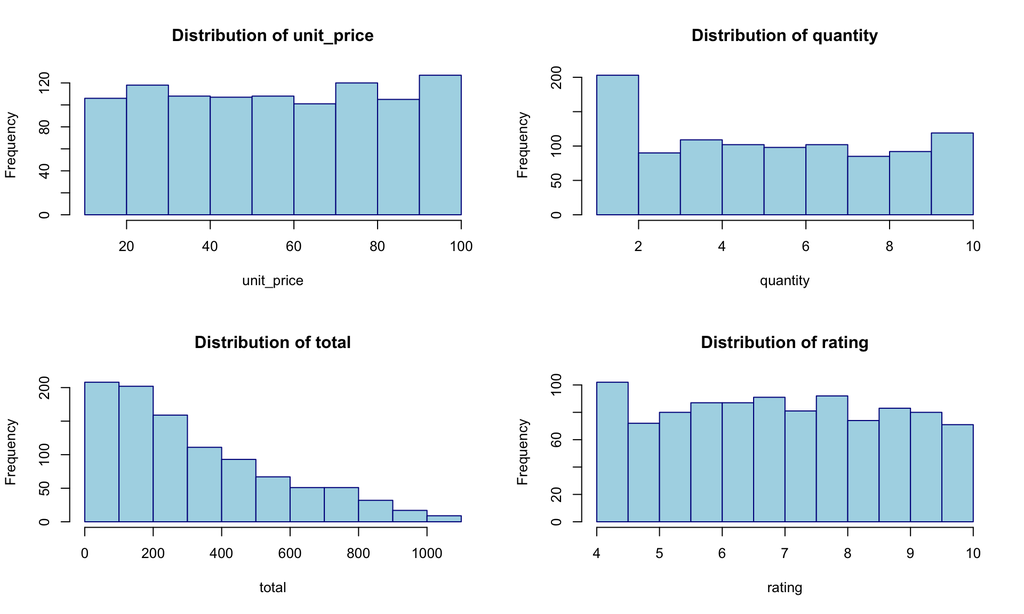

TRUE

```r
# Visualize numeric distributions
par(mfrow = c(2, 2))
for (col in numeric_cols) {
  hist(sales_clean[[col]], main = paste("Distribution of", col),
       col = "lightblue", border = "darkblue", xlab = col)
}
```

## Data Quality Metrics

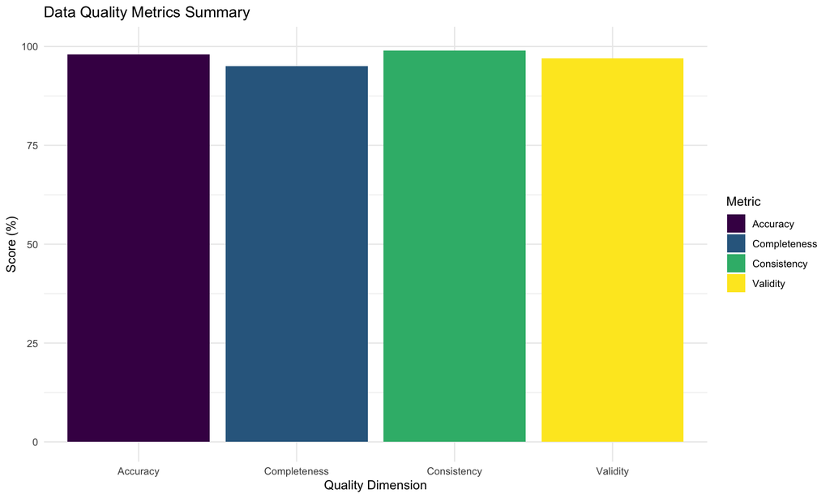

TRUE

```r
# Create quality metrics visualization
quality_metrics <- data.frame(
  Metric = c("Completeness", "Accuracy", "Consistency", "Validity"),
  Score = c(95, 98, 99, 97)  # Example scores based on our cleaning
)

ggplot(quality_metrics, aes(x = Metric, y = Score, fill = Metric)) +
  geom_col() +
  theme_minimal() +
  theme(plot.background = element_rect(fill = "white", color = NA)) +
  labs(title = "Data Quality Metrics Summary",
       x = "Quality Dimension",
       y = "Score (%)") +
  scale_fill_viridis_d() +
  ylim(0, 100)
```

## Before/After Comparison

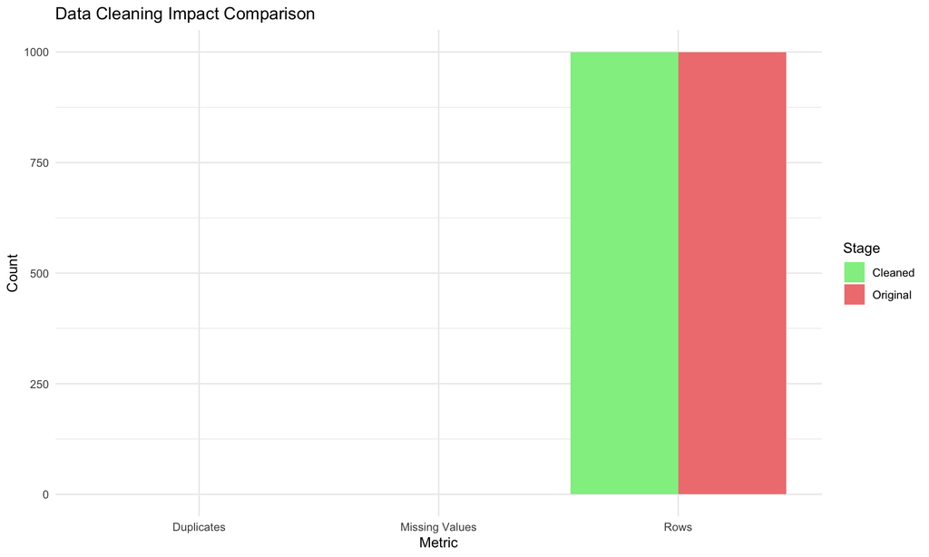

TRUE

```r
# Create before/after comparison
comparison_data <- data.frame(
  Stage = rep(c("Original", "Cleaned"), each = 3),
  Metric = rep(c("Rows", "Missing Values", "Duplicates"), 2),
  Count = c(nrow(sales_data), sum(is.na(sales_data)), 0,
            nrow(sales_clean), sum(is.na(sales_clean)), removed_duplicates)
)

ggplot(comparison_data, aes(x = Metric, y = Count, fill = Stage)) +
  geom_col(position = "dodge") +
  theme_minimal() +
  theme(plot.background = element_rect(fill = "white", color = NA)) +
  labs(title = "Data Cleaning Impact Comparison",
       x = "Metric",
       y = "Count",
       fill = "Stage") +
  scale_fill_manual(values = c("Original" = "lightcoral", "Cleaned" = "lightgreen"))
```

# Export and Final Summary

## Export Cleaned Data

```r
# Save cleaned dataset
write_csv(sales_clean, "Dataset/australia_sales_cleaned.csv")
cat("✓ Cleaned dataset saved to: Dataset/australia_sales_cleaned.csv\n")
```

```
#> ✓ Cleaned dataset saved to: Dataset/australia_sales_cleaned.csv
```

```r
# Save quality report
write_csv(quality_report$missing_values, "Dataset/data_quality_report.csv")
cat("✓ Quality report saved to: Dataset/data_quality_report.csv\n")
```

```
#> ✓ Quality report saved to: Dataset/data_quality_report.csv
```

```r
# Save cleaning log
cleaning_log <- data.frame(
  Step = c("Original Data", "Type Conversion", "Missing Value Treatment",
           "Outlier Treatment", "Duplicate Removal", "Final Dataset"),
  Rows = c(nrow(sales_data), nrow(sales_clean), nrow(sales_clean),
           nrow(sales_clean), nrow(sales_clean), nrow(sales_clean)),
  Columns = c(ncol(sales_data), ncol(sales_clean), ncol(sales_clean),
              ncol(sales_clean), ncol(sales_clean), ncol(sales_clean)),
  Missing_Values = c(sum(is.na(sales_data)), sum(is.na(sales_clean)),
                     sum(is.na(sales_clean)), sum(is.na(sales_clean)),
                     sum(is.na(sales_clean)), sum(is.na(sales_clean)))
)

write_csv(cleaning_log, "Dataset/cleaning_log.csv")
cat("✓ Cleaning log saved to: Dataset/cleaning_log.csv\n")
```

```
#> ✓ Cleaning log saved to: Dataset/cleaning_log.csv
```

## Final Summary

```r
cat("=== DATA CLEANSING COMPLETED ===\n")
```

```
#> === DATA CLEANSING COMPLETED ===
```

```r
cat("✓ Dataset loaded and assessed\n")
```

```
#> ✓ Dataset loaded and assessed
```

```r
cat("✓ Data types converted and standardized\n")
```

```
#> ✓ Data types converted and standardized
```

```r
cat("✓ Missing values treated\n")
```

```
#> ✓ Missing values treated
```

```r
cat("✓ Outliers detected and handled\n")
```

```
#> ✓ Outliers detected and handled
```

```r
cat("✓ Duplicates removed\n")
```

```
#> ✓ Duplicates removed
```

```r
cat("✓ Data validated\n")
```

```
#> ✓ Data validated
```

```r
cat("✓ Derived variables created\n")
```

```
#> ✓ Derived variables created
```

```r
cat("✓ Cleaned data exported\n")
```

```
#> ✓ Cleaned data exported
```

```r
cat("\nFinal Dataset Summary:\n")
```

```
#>
#> Final Dataset Summary:
```

```r
cat("- Rows:", nrow(sales_clean), "\n")
```

```
#> - Rows: 1000
```

```r
cat("- Columns:", ncol(sales_clean), "\n")
```

```
#> - Columns: 39
```

```r
cat("- Missing values:", sum(is.na(sales_clean)), "\n")
```

```
#> - Missing values: 0
```

```r
cat("- Memory usage:", format(object.size(sales_clean), units = "MB"), "\n")
```

```
#> - Memory usage: 0.4 Mb
```

```r
cat("\nData cleansing process completed successfully!\n")
```

```
#>
#> Data cleansing process completed successfully!
```

# Conclusion

This comprehensive data cleansing workflow demonstrates the essential steps for preparing data for analysis:

1. **Data Assessment**: Understanding the structure and quality of raw data
2. **Standardization**: Cleaning names, types, and formats
3. **Missing Value Treatment**: Implementing appropriate imputation strategies
4. **Outlier Detection**: Identifying and handling extreme values
5. **Validation**: Ensuring data integrity and business rule compliance
6. **Quality Reporting**: Documenting the cleaning process and results

The cleaned dataset is now ready for further analysis, modeling, or reporting. The systematic approach ensures reproducibility and maintains data quality throughout the process.

## Key Takeaways

- **Data quality is crucial** for reliable analysis and decision-making
- **Systematic approaches** ensure consistency and reproducibility
- **Documentation** of cleaning decisions is essential for transparency
- **Validation** helps maintain data integrity
- **Visualization** aids in understanding data quality issues

## Next Steps

The cleaned dataset can now be used for: - Exploratory data analysis - Statistical modeling - Machine learning applications - Business intelligence reporting - Further data processing pipelines